# Risk Factor Analysis

## Outcome Variable

**Outcome Variable:** haz

## Predictor Variables

**Intervention Variable:** gagebrth

**Adjustment Set:**

unadjusted

## Stratifying Variables

The analysis was stratified on these variable(s):

- agecat
- studyid
- country

## Data Summary

| agecat | studyid | country | gagebrth | n_cell | n |
| --- | --- | --- | --- | --- | --- |
| Birth | ki1000108-CMC-V-BCS-2002 | INDIA | Full or late term | 57 | 90 |
| Birth | ki1000108-CMC-V-BCS-2002 | INDIA | Preterm | 10 | 90 |
| Birth | ki1000108-CMC-V-BCS-2002 | INDIA | Early term | 23 | 90 |
| Birth | ki1000108-IRC | INDIA | Full or late term | 238 | 369 |
| Birth | ki1000108-IRC | INDIA | Preterm | 36 | 369 |
| Birth | ki1000108-IRC | INDIA | Early term | 95 | 369 |
| Birth | ki1000109-EE | PAKISTAN | Full or late term | 0 | 2 |
| Birth | ki1000109-EE | PAKISTAN | Preterm | 1 | 2 |
| Birth | ki1000109-EE | PAKISTAN | Early term | 1 | 2 |
| Birth | ki1000304b-SAS-CompFeed | INDIA | Full or late term | 1 | 187 |
| Birth | ki1000304b-SAS-CompFeed | INDIA | Preterm | 171 | 187 |
| Birth | ki1000304b-SAS-CompFeed | INDIA | Early term | 15 | 187 |
| Birth | ki1017093c-NIH-Crypto | BANGLADESH | Full or late term | 7 | 27 |
| Birth | ki1017093c-NIH-Crypto | BANGLADESH | Preterm | 5 | 27 |
| Birth | ki1017093c-NIH-Crypto | BANGLADESH | Early term | 15 | 27 |
| Birth | ki1101329-Keneba | GAMBIA | Full or late term | 734 | 1515 |
| Birth | ki1101329-Keneba | GAMBIA | Preterm | 235 | 1515 |
| Birth | ki1101329-Keneba | GAMBIA | Early term | 546 | 1515 |
| Birth | ki1119695-PROBIT | BELARUS | Full or late term | 7095 | 13884 |
| Birth | ki1119695-PROBIT | BELARUS | Preterm | 472 | 13884 |
| Birth | ki1119695-PROBIT | BELARUS | Early term | 6317 | 13884 |
| Birth | ki1135781-COHORTS | GUATEMALA | Full or late term | 341 | 617 |
| Birth | ki1135781-COHORTS | GUATEMALA | Preterm | 95 | 617 |
| Birth | ki1135781-COHORTS | GUATEMALA | Early term | 181 | 617 |
| Birth | ki1135781-COHORTS | INDIA | Full or late term | 570 | 1293 |
| Birth | ki1135781-COHORTS | INDIA | Preterm | 285 | 1293 |
| Birth | ki1135781-COHORTS | INDIA | Early term | 438 | 1293 |
| Birth | ki1135781-COHORTS | PHILIPPINES | Full or late term | 1164 | 3024 |
| Birth | ki1135781-COHORTS | PHILIPPINES | Preterm | 649 | 3024 |
| Birth | ki1135781-COHORTS | PHILIPPINES | Early term | 1211 | 3024 |

[output cut: 69 more lines]

The following strata were considered:

- agecat: 24 months, studyid: ki1000108-CMC-V-BCS-2002, country: INDIA
- agecat: 24 months, studyid: ki1000108-IRC, country: INDIA
- agecat: 24 months, studyid: ki1017093c-NIH-Crypto, country: BANGLADESH
- agecat: 24 months, studyid: ki1066203-TanzaniaChild2, country: TANZANIA, UNITED REPUBLIC OF
- agecat: 24 months, studyid: ki1101329-Keneba, country: GAMBIA
- agecat: 24 months, studyid: ki1119695-PROBIT, country: BELARUS
- agecat: 24 months, studyid: ki1135781-COHORTS, country: GUATEMALA
- agecat: 24 months, studyid: ki1135781-COHORTS, country: INDIA
- agecat: 24 months, studyid: ki1135781-COHORTS, country: PHILIPPINES
- agecat: 24 months, studyid: kiGH5241-JiVitA-3, country: BANGLADESH
- agecat: 6 months, studyid: ki1000108-CMC-V-BCS-2002, country: INDIA
- agecat: 6 months, studyid: ki1000108-IRC, country: INDIA
- agecat: 6 months, studyid: ki1000109-EE, country: PAKISTAN
- agecat: 6 months, studyid: ki1000304b-SAS-CompFeed, country: INDIA
- agecat: 6 months, studyid: ki1017093c-NIH-Crypto, country: BANGLADESH
- agecat: 6 months, studyid: ki1066203-TanzaniaChild2, country: TANZANIA, UNITED REPUBLIC OF
- agecat: 6 months, studyid: ki1101329-Keneba, country: GAMBIA
- agecat: 6 months, studyid: ki1119695-PROBIT, country: BELARUS
- agecat: 6 months, studyid: ki1135781-COHORTS, country: GUATEMALA
- agecat: 6 months, studyid: ki1135781-COHORTS, country: INDIA
- agecat: 6 months, studyid: ki1135781-COHORTS, country: PHILIPPINES
- agecat: 6 months, studyid: kiGH5241-JiVitA-3, country: BANGLADESH
- agecat: Birth, studyid: ki1000108-CMC-V-BCS-2002, country: INDIA
- agecat: Birth, studyid: ki1000108-IRC, country: INDIA
- agecat: Birth, studyid: ki1000109-EE, country: PAKISTAN
- agecat: Birth, studyid: ki1000304b-SAS-CompFeed, country: INDIA
- agecat: Birth, studyid: ki1017093c-NIH-Crypto, country: BANGLADESH
- agecat: Birth, studyid: ki1101329-Keneba, country: GAMBIA
- agecat: Birth, studyid: ki1119695-PROBIT, country: BELARUS
- agecat: Birth, studyid: ki1135781-COHORTS, country: GUATEMALA
- agecat: Birth, studyid: ki1135781-COHORTS, country: INDIA
- agecat: Birth, studyid: ki1135781-COHORTS, country: PHILIPPINES
- agecat: Birth, studyid: kiGH5241-JiVitA-3, country: BANGLADESH

### Dropped Strata

Some strata were dropped due to rare outcomes:

- agecat: Birth, studyid: ki1000109-EE, country: PAKISTAN
- agecat: Birth, studyid: ki1000304b-SAS-CompFeed, country: INDIA
- agecat: 24 months, studyid: ki1066203-TanzaniaChild2, country: TANZANIA, UNITED REPUBLIC OF

## Methods Detail

We’re interested in the causal parameters $E[Y_a]$ for all values of $a \in \mathcal{A}$. These parameters represent the mean outcome if, possibly contrary to fact, we intervened to set all units to have $A=a$. Under the randomization and positivity assumptions, these are identified by the statistical parameters $\psi_a=E_W[E_{Y|A,W}(Y|A=a,W)]$. In addition, we’re interested in the mean of $Y$, $E[Y]$ under no intervention (the observed mean). We will estimate these parameters by using SuperLearner to fit the relevant likelihood factors – $E_{Y|A,W}(Y|A=a,W)$ and $p(A=a|W)$, and then updating our likelihood fit using a joint TMLE.

For unadjusted analyses ($W=\{\}$), initial likelihoods were estimated using Lrnr_glm to estimate the simple $E(Y|A)$ and Lrnr_mean to estimate $p(A)$. For adjusted analyses, a small library containing Lrnr_glmnet, Lrnr_xgboost, and Lrnr_mean was used.

Having estimated these parameters, we will then use the delta method to estimate relative risks and attributable risks relative to a prespecified baseline level of $A$.

# Results Detail

## Results Plots

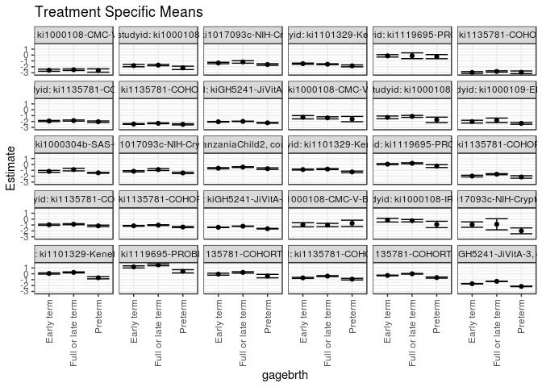

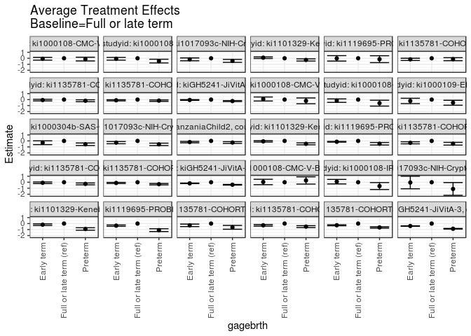

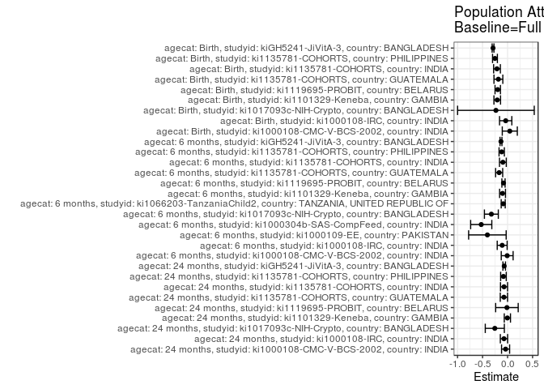

## Results Table

### Parameter: TSM

| agecat | studyid | country | intervention_level | baseline_level | estimate | ci_lower | ci_upper |
| --- | --- | --- | --- | --- | --- | --- | --- |
| Birth | ki1000108-CMC-V-BCS-2002 | INDIA | Full or late term | NA | -1.0098246 | -1.2904190 | -0.7292301 |
| Birth | ki1000108-CMC-V-BCS-2002 | INDIA | Preterm | NA | -0.7140000 | -1.2494603 | -0.1785397 |
| Birth | ki1000108-CMC-V-BCS-2002 | INDIA | Early term | NA | -0.9647826 | -1.3170868 | -0.6124784 |
| Birth | ki1000108-IRC | INDIA | Full or late term | NA | -0.2726891 | -0.4770060 | -0.0683722 |
| Birth | ki1000108-IRC | INDIA | Preterm | NA | -0.9105556 | -1.4543481 | -0.3667630 |
| Birth | ki1000108-IRC | INDIA | Early term | NA | -0.1770526 | -0.4916498 | 0.1375445 |
| Birth | ki1017093c-NIH-Crypto | BANGLADESH | Full or late term | NA | -0.8771429 | -1.8202279 | 0.0659422 |
| Birth | ki1017093c-NIH-Crypto | BANGLADESH | Preterm | NA | -1.9980000 | -2.4964582 | -1.4995418 |
| Birth | ki1017093c-NIH-Crypto | BANGLADESH | Early term | NA | -0.9226667 | -1.3784537 | -0.4668796 |
| Birth | ki1101329-Keneba | GAMBIA | Full or late term | NA | 0.2354632 | 0.1496110 | 0.3213154 |
| Birth | ki1101329-Keneba | GAMBIA | Preterm | NA | -0.6711064 | -0.8570478 | -0.4851649 |
| Birth | ki1101329-Keneba | GAMBIA | Early term | NA | 0.0523260 | -0.0487688 | 0.1534208 |
| Birth | ki1119695-PROBIT | BELARUS | Full or late term | NA | 1.5222185 | 1.3700195 | 1.6744174 |
| Birth | ki1119695-PROBIT | BELARUS | Preterm | NA | 0.4241949 | 0.1475613 | 0.7008286 |
| Birth | ki1119695-PROBIT | BELARUS | Early term | NA | 1.1718490 | 0.9900828 | 1.3536152 |
| Birth | ki1135781-COHORTS | GUATEMALA | Full or late term | NA | 0.2367449 | 0.1129997 | 0.3604901 |
| Birth | ki1135781-COHORTS | GUATEMALA | Preterm | NA | -0.3893684 | -0.6838031 | -0.0949338 |
| Birth | ki1135781-COHORTS | GUATEMALA | Early term | NA | -0.0607182 | -0.2277653 | 0.1063288 |
| Birth | ki1135781-COHORTS | INDIA | Full or late term | NA | -0.3955789 | -0.4832187 | -0.3079392 |
| Birth | ki1135781-COHORTS | INDIA | Preterm | NA | -0.9073333 | -1.0436769 | -0.7709898 |
| Birth | ki1135781-COHORTS | INDIA | Early term | NA | -0.6873516 | -0.7862577 | -0.5884455 |
| Birth | ki1135781-COHORTS | PHILIPPINES | Full or late term | NA | 0.0027663 | -0.0556001 | 0.0611327 |
| Birth | ki1135781-COHORTS | PHILIPPINES | Preterm | NA | -0.6426810 | -0.7403472 | -0.5450149 |
| Birth | ki1135781-COHORTS | PHILIPPINES | Early term | NA | -0.2806276 | -0.3376182 | -0.2236370 |
| Birth | kiGH5241-JiVitA-3 | BANGLADESH | Full or late term | NA | -1.2752148 | -1.2990276 | -1.2514020 |
| Birth | kiGH5241-JiVitA-3 | BANGLADESH | Preterm | NA | -2.1410864 | -2.1880631 | -2.0941096 |
| Birth | kiGH5241-JiVitA-3 | BANGLADESH | Early term | NA | -1.6843181 | -1.7170136 | -1.6516225 |
| 6 months | ki1000108-CMC-V-BCS-2002 | INDIA | Full or late term | NA | -1.3778145 | -1.5599142 | -1.1957148 |
| 6 months | ki1000108-CMC-V-BCS-2002 | INDIA | Preterm | NA | -1.5883013 | -2.0368105 | -1.1397921 |
| 6 months | ki1000108-CMC-V-BCS-2002 | INDIA | Early term | NA | -1.2784940 | -1.5569704 | -1.0000176 |

[output cut: 60 more lines]

### Parameter: E(Y)

| agecat | studyid | country | intervention_level | baseline_level | estimate | ci_lower | ci_upper |
| --- | --- | --- | --- | --- | --- | --- | --- |
| Birth | ki1000108-CMC-V-BCS-2002 | INDIA | NA | NA | -0.9654444 | -1.1742112 | -0.7566777 |
| Birth | ki1000108-IRC | INDIA | NA | NA | -0.3102981 | -0.4751168 | -0.1454794 |
| Birth | ki1017093c-NIH-Crypto | BANGLADESH | NA | NA | -1.1100000 | -1.5086894 | -0.7113106 |
| Birth | ki1101329-Keneba | GAMBIA | NA | NA | 0.0288383 | -0.0354675 | 0.0931441 |
| Birth | ki1119695-PROBIT | BELARUS | NA | NA | 1.3254775 | 1.1669293 | 1.4840258 |
| Birth | ki1135781-COHORTS | GUATEMALA | NA | NA | 0.0530794 | -0.0441925 | 0.1503513 |
| Birth | ki1135781-COHORTS | INDIA | NA | NA | -0.6072158 | -0.6675691 | -0.5468624 |
| Birth | ki1135781-COHORTS | PHILIPPINES | NA | NA | -0.2492460 | -0.2884729 | -0.2100192 |
| Birth | kiGH5241-JiVitA-3 | BANGLADESH | NA | NA | -1.5660681 | -1.5858219 | -1.5463144 |
| 6 months | ki1000108-CMC-V-BCS-2002 | INDIA | NA | NA | -1.3856004 | -1.5319935 | -1.2392073 |
| 6 months | ki1000108-IRC | INDIA | NA | NA | -1.2321263 | -1.3660720 | -1.0981806 |
| 6 months | ki1000109-EE | PAKISTAN | NA | NA | -2.2004704 | -2.3234073 | -2.0775336 |
| 6 months | ki1000304b-SAS-CompFeed | INDIA | NA | NA | -1.4018312 | -1.4804646 | -1.3231978 |
| 6 months | ki1017093c-NIH-Crypto | BANGLADESH | NA | NA | -1.1986783 | -1.2700937 | -1.1272630 |
| 6 months | ki1066203-TanzaniaChild2 | TANZANIA, UNITED REPUBLIC OF | NA | NA | -0.5419570 | -0.5926042 | -0.4913098 |
| 6 months | ki1101329-Keneba | GAMBIA | NA | NA | -0.8948084 | -0.9510697 | -0.8385471 |
| 6 months | ki1119695-PROBIT | BELARUS | NA | NA | 0.1069986 | 0.0122286 | 0.2017686 |
| 6 months | ki1135781-COHORTS | GUATEMALA | NA | NA | -1.8315428 | -1.9081267 | -1.7549589 |
| 6 months | ki1135781-COHORTS | INDIA | NA | NA | -0.9630335 | -1.0220763 | -0.9039908 |
| 6 months | ki1135781-COHORTS | PHILIPPINES | NA | NA | -1.1409862 | -1.1830414 | -1.0989310 |
| 6 months | kiGH5241-JiVitA-3 | BANGLADESH | NA | NA | -1.3404486 | -1.3659169 | -1.3149804 |
| 24 months | ki1000108-CMC-V-BCS-2002 | INDIA | NA | NA | -2.5330857 | -2.6360668 | -2.4301046 |
| 24 months | ki1000108-IRC | INDIA | NA | NA | -1.7805128 | -1.8756216 | -1.6854041 |
| 24 months | ki1017093c-NIH-Crypto | BANGLADESH | NA | NA | -1.4295331 | -1.5127726 | -1.3462935 |
| 24 months | ki1101329-Keneba | GAMBIA | NA | NA | -1.5664092 | -1.6263058 | -1.5065125 |
| 24 months | ki1119695-PROBIT | BELARUS | NA | NA | -0.1314048 | -0.4282725 | 0.1654630 |
| 24 months | ki1135781-COHORTS | GUATEMALA | NA | NA | -2.8606184 | -2.9431264 | -2.7781104 |
| 24 months | ki1135781-COHORTS | INDIA | NA | NA | -1.9130810 | -1.9742771 | -1.8518850 |
| 24 months | ki1135781-COHORTS | PHILIPPINES | NA | NA | -2.3902929 | -2.4353250 | -2.3452608 |
| 24 months | kiGH5241-JiVitA-3 | BANGLADESH | NA | NA | -2.0468674 | -2.0777591 | -2.0159757 |

### Parameter: ATE

| agecat | studyid | country | intervention_level | baseline_level | estimate | ci_lower | ci_upper |
| --- | --- | --- | --- | --- | --- | --- | --- |
| Birth | ki1000108-CMC-V-BCS-2002 | INDIA | Full or late term | Full or late term | 0.0000000 | 0.0000000 | 0.0000000 |
| Birth | ki1000108-CMC-V-BCS-2002 | INDIA | Preterm | Full or late term | 0.2958246 | -0.3087008 | 0.9003499 |
| Birth | ki1000108-CMC-V-BCS-2002 | INDIA | Early term | Full or late term | 0.0450420 | -0.4053484 | 0.4954323 |
| Birth | ki1000108-IRC | INDIA | Full or late term | Full or late term | 0.0000000 | 0.0000000 | 0.0000000 |
| Birth | ki1000108-IRC | INDIA | Preterm | Full or late term | -0.6378665 | -1.2187759 | -0.0569570 |
| Birth | ki1000108-IRC | INDIA | Early term | Full or late term | 0.0956364 | -0.2794859 | 0.4707588 |
| Birth | ki1017093c-NIH-Crypto | BANGLADESH | Full or late term | Full or late term | 0.0000000 | 0.0000000 | 0.0000000 |
| Birth | ki1017093c-NIH-Crypto | BANGLADESH | Preterm | Full or late term | -1.1208571 | -2.1875671 | -0.0541472 |
| Birth | ki1017093c-NIH-Crypto | BANGLADESH | Early term | Full or late term | -0.0455238 | -1.0929737 | 1.0019261 |
| Birth | ki1101329-Keneba | GAMBIA | Full or late term | Full or late term | 0.0000000 | 0.0000000 | 0.0000000 |
| Birth | ki1101329-Keneba | GAMBIA | Preterm | Full or late term | -0.9065696 | -1.1113740 | -0.7017652 |
| Birth | ki1101329-Keneba | GAMBIA | Early term | Full or late term | -0.1831372 | -0.3157674 | -0.0505070 |
| Birth | ki1119695-PROBIT | BELARUS | Full or late term | Full or late term | 0.0000000 | 0.0000000 | 0.0000000 |
| Birth | ki1119695-PROBIT | BELARUS | Preterm | Full or late term | -1.0980235 | -1.3343288 | -0.8617183 |
| Birth | ki1119695-PROBIT | BELARUS | Early term | Full or late term | -0.3503695 | -0.4675806 | -0.2331584 |
| Birth | ki1135781-COHORTS | GUATEMALA | Full or late term | Full or late term | 0.0000000 | 0.0000000 | 0.0000000 |
| Birth | ki1135781-COHORTS | GUATEMALA | Preterm | Full or late term | -0.6261133 | -0.9454950 | -0.3067316 |
| Birth | ki1135781-COHORTS | GUATEMALA | Early term | Full or late term | -0.2974631 | -0.5053515 | -0.0895747 |
| Birth | ki1135781-COHORTS | INDIA | Full or late term | Full or late term | 0.0000000 | 0.0000000 | 0.0000000 |
| Birth | ki1135781-COHORTS | INDIA | Preterm | Full or late term | -0.5117544 | -0.6738355 | -0.3496733 |
| Birth | ki1135781-COHORTS | INDIA | Early term | Full or late term | -0.2917727 | -0.4239208 | -0.1596245 |
| Birth | ki1135781-COHORTS | PHILIPPINES | Full or late term | Full or late term | 0.0000000 | 0.0000000 | 0.0000000 |
| Birth | ki1135781-COHORTS | PHILIPPINES | Preterm | Full or late term | -0.6454474 | -0.7592248 | -0.5316699 |
| Birth | ki1135781-COHORTS | PHILIPPINES | Early term | Full or late term | -0.2833939 | -0.3649694 | -0.2018184 |
| Birth | kiGH5241-JiVitA-3 | BANGLADESH | Full or late term | Full or late term | 0.0000000 | 0.0000000 | 0.0000000 |
| Birth | kiGH5241-JiVitA-3 | BANGLADESH | Preterm | Full or late term | -0.8658715 | -0.9192642 | -0.8124789 |
| Birth | kiGH5241-JiVitA-3 | BANGLADESH | Early term | Full or late term | -0.4091033 | -0.4467212 | -0.3714853 |
| 6 months | ki1000108-CMC-V-BCS-2002 | INDIA | Full or late term | Full or late term | 0.0000000 | 0.0000000 | 0.0000000 |
| 6 months | ki1000108-CMC-V-BCS-2002 | INDIA | Preterm | Full or late term | -0.2104868 | -0.6945538 | 0.2735801 |
| 6 months | ki1000108-CMC-V-BCS-2002 | INDIA | Early term | Full or late term | 0.0993205 | -0.2334097 | 0.4320507 |

[output cut: 60 more lines]

### Parameter: PAR

| agecat | studyid | country | intervention_level | baseline_level | estimate | ci_lower | ci_upper |
| --- | --- | --- | --- | --- | --- | --- | --- |
| Birth | ki1000108-CMC-V-BCS-2002 | INDIA | Full or late term | NA | 0.0443801 | -0.1059130 | 0.1946732 |
| Birth | ki1000108-IRC | INDIA | Full or late term | NA | -0.0376090 | -0.1603289 | 0.0851108 |
| Birth | ki1017093c-NIH-Crypto | BANGLADESH | Full or late term | NA | -0.2328571 | -0.9991387 | 0.5334244 |
| Birth | ki1101329-Keneba | GAMBIA | Full or late term | NA | -0.2066249 | -0.2726847 | -0.1405652 |
| Birth | ki1119695-PROBIT | BELARUS | Full or late term | NA | -0.1967409 | -0.2508387 | -0.1426431 |
| Birth | ki1135781-COHORTS | GUATEMALA | Full or late term | NA | -0.1836655 | -0.2722580 | -0.0950729 |
| Birth | ki1135781-COHORTS | INDIA | Full or late term | NA | -0.2116368 | -0.2791008 | -0.1441729 |
| Birth | ki1135781-COHORTS | PHILIPPINES | Full or late term | NA | -0.2520124 | -0.3002079 | -0.2038168 |
| Birth | kiGH5241-JiVitA-3 | BANGLADESH | Full or late term | NA | -0.2908533 | -0.3088105 | -0.2728961 |
| 6 months | ki1000108-CMC-V-BCS-2002 | INDIA | Full or late term | NA | -0.0077859 | -0.1264140 | 0.1108421 |
| 6 months | ki1000108-IRC | INDIA | Full or late term | NA | -0.1077956 | -0.2071602 | -0.0084311 |
| 6 months | ki1000109-EE | PAKISTAN | Full or late term | NA | -0.4034704 | -0.7787220 | -0.0282189 |
| 6 months | ki1000304b-SAS-CompFeed | INDIA | Full or late term | NA | -0.5266312 | -0.7381017 | -0.3151607 |
| 6 months | ki1017093c-NIH-Crypto | BANGLADESH | Full or late term | NA | -0.3239686 | -0.4628198 | -0.1851175 |
| 6 months | ki1066203-TanzaniaChild2 | TANZANIA, UNITED REPUBLIC OF | Full or late term | NA | -0.0871519 | -0.1274405 | -0.0468634 |
| 6 months | ki1101329-Keneba | GAMBIA | Full or late term | NA | -0.1003568 | -0.1592207 | -0.0414929 |
| 6 months | ki1119695-PROBIT | BELARUS | Full or late term | NA | -0.0816403 | -0.1137051 | -0.0495754 |
| 6 months | ki1135781-COHORTS | GUATEMALA | Full or late term | NA | -0.1684579 | -0.2391560 | -0.0977599 |
| 6 months | ki1135781-COHORTS | INDIA | Full or late term | NA | -0.0937026 | -0.1614819 | -0.0259232 |
| 6 months | ki1135781-COHORTS | PHILIPPINES | Full or late term | NA | -0.1174454 | -0.1704061 | -0.0644846 |
| 6 months | kiGH5241-JiVitA-3 | BANGLADESH | Full or late term | NA | -0.1317694 | -0.1512673 | -0.1122715 |
| 24 months | ki1000108-CMC-V-BCS-2002 | INDIA | Full or late term | NA | -0.0396901 | -0.1202391 | 0.0408590 |
| 24 months | ki1000108-IRC | INDIA | Full or late term | NA | -0.0717795 | -0.1445949 | 0.0010359 |
| 24 months | ki1017093c-NIH-Crypto | BANGLADESH | Full or late term | NA | -0.2552293 | -0.4458759 | -0.0645826 |
| 24 months | ki1101329-Keneba | GAMBIA | Full or late term | NA | -0.0039705 | -0.0660300 | 0.0580890 |
| 24 months | ki1119695-PROBIT | BELARUS | Full or late term | NA | -0.0129274 | -0.2382745 | 0.2124198 |
| 24 months | ki1135781-COHORTS | GUATEMALA | Full or late term | NA | -0.0731251 | -0.1459268 | -0.0003234 |
| 24 months | ki1135781-COHORTS | INDIA | Full or late term | NA | -0.0707094 | -0.1413429 | -0.0000758 |
| 24 months | ki1135781-COHORTS | PHILIPPINES | Full or late term | NA | -0.0824784 | -0.1382989 | -0.0266579 |
| 24 months | kiGH5241-JiVitA-3 | BANGLADESH | Full or late term | NA | -0.0673672 | -0.0930007 | -0.0417338 |